# Phenology Project update

Pat Dumandan

### **Project Overview**

Reproductive phenology is a key descriptor of an important ecological strategy of organisms (Schwartz, 2003). Reproduction is a period in the life cycle of organisms that requires high energetic costs. As such, efforts of breeding individuals need to be optimized to ensure that they are able to exploit resources while avoiding unfavorable conditions (Bradshaw and Holzapfel 2007). Thus, identifying the abiotic (e.g., climate change) and biotic conditions (e.g., presence of competitors) that may drive shifts in the timing of these reproductive events is important in understanding how the demography of wildlife populations may vary in future landscape scenarios. However, our understanding of how most organisms time these events given their environmental context is generally lacking. This is especially true for small mammals in the wild that are often challenging to obtain data for. Here, we describe the reproductive phenophases of rodents monitored in a study site near Portal, Arizona and determine how biotic conditions (i.e., competitive interactions) influence their reproductive phenology.

### **Methods**

**Data Source**  
*(Methods for Data collection at Portal,AZ and sexing rodents)*

**Data Curation and Manipulation**

We assembled a dataset on the observed abundance of individual small mammals in Portal, Arizona that were exhibiting reproductive characteristics (Oregon manual). We used the functionalities of the ‘portalr’ package (Yenni et al. 2019) to obtain partially cleaned individual-level data (i.e., removal of data with bad tags, periods, etc.). From this cleaned dataset, we created subsets for each type of plot (control and exclosure) and sex (male and female). For our analysis, we assigned individuals as reproductive males for those that had testes described to be scrotal (descended), recently scrotal, and had minor signs of scrotal testes. We identified reproductive females as those that were described to be pregnant (after palpating the belly), with either red or enlarged (or both) nipples, and those with swollen or plugged (or both) vaginas. To limit the introduction of biases in our dataset through the inclusion of juveniles, we identified a minimum threshold of the body mass for the breeding individuals for each species and sex. Then, we filtered out individuals that had a body mass below the threshold for each group. Finally, we calculated the monthly proportion of breeding individuals for each species and sex by dividing the number of reproductive individuals observed by the total number of individuals for each species and sex in each plot type in each year.

```r
require(portalr)
require(dplyr)
require(ggplot2)
require (lme4)
require(rstan)
require(brms)
require(rstanarm)
require(bayesplot)

options(mc.cores = parallel::detectCores())
rstan_options(auto_write = TRUE)

####load cleaned individual-level data####
Portal_data_indiv=summarize_individual_rodents(
  path = get_default_data_path(),
  clean = TRUE,
  type = "Rodents",
  length = "all",
  unknowns = FALSE,
  time = "date",
  fillweight = FALSE,
  min_plots = 1,
  min_traps = 1,
  download_if_missing = TRUE,
  quiet = FALSE
)%>%filter(!(treatment=="removal")& !is.na(treatment)& !is.na(sex))%>%
  mutate(month=as.character(month))

# add columns for reproductive traits
Portal_data=load_rodent_data(clean = TRUE)
Portal_rodent=Portal_data[["rodent_data"]]%>%mutate(month=factor(month))%>%
  filter(!is.na(sex))

#create full dataset without removal plots
portal1=left_join(Portal_data_indiv, Portal_rodent)%>%
  filter(!(treatment=="removal")& !is.na(treatment)& !is.na(sex))%>%
  mutate(month=as.integer(month), Month=recode(month, "1"= "Jan", "2"="Feb", "3"="Mar", "4"="Apr",
                                           "5"="May","6"="Jun", "7"="Jul", "8"="Aug", "9"="Sept",
                                           "10"="Oct","11"="Nov", "12"="Dec"))%>%
  select(period, month, Month, day, year, plot, stake,
         treatment, species, sex, reprod, vagina, nipples,lactation, pregnant, testes,hfl,wgt, tag)

str(portal1)
```

```
## 'data.frame':    58345 obs. of  19 variables:
##  $ period   : num  1 1 1 1 1 1 1 1 1 1 ...
##  $ month    : int  7 7 7 7 7 7 7 7 7 7 ...
##  $ Month    : chr  "Jul" "Jul" "Jul" "Jul" ...
##  $ day      : int  16 16 16 16 16 16 16 16 16 16 ...
##  $ year     : int  1977 1977 1977 1977 1977 1977 1977 1977 1977 1977 ...
##  $ plot     : int  2 3 2 7 3 1 2 1 1 6 ...
##  $ stake    : int  16 23 25 25 26 27 31 36 42 46 ...
##  $ treatment: chr  "control" "control" "control" "control" ...
##  $ species  : chr  "NA" "NA" "DM" "DM" ...
##  $ sex      : chr  "M" "M" "F" "M" ...
##  $ reprod   : chr  "Z" "Z" NA "Z" ...
##  $ vagina   : chr  NA NA NA NA ...
##  $ nipples  : chr  NA NA NA NA ...
##  $ lactation: chr  NA NA NA NA ...
##  $ pregnant : chr  NA NA NA NA ...
##  $ testes   : chr  NA NA NA NA ...
##  $ hfl      : int  32 33 37 36 35 14 NA 37 34 20 ...
##  $ wgt      : num  NA NA NA NA NA NA NA NA NA NA ...
##  $ tag      : chr  "0" "0" "0" "0" ...
```

```r
portal_male=portal1%>%filter(sex=="M") #49% of individuals are males
head(portal_male)
```

```
##   period month Month day year plot stake treatment species sex reprod vagina
## 1      1     7   Jul  16 1977    2    16   control      NA   M      Z   <NA>
## 2      1     7   Jul  16 1977    3    23   control      NA   M      Z   <NA>
## 3      1     7   Jul  16 1977    7    25   control      DM   M      Z   <NA>
## 4      1     7   Jul  16 1977    3    26   control      DM   M      Z   <NA>
## 5      1     7   Jul  16 1977    1    27   control      PF   M   <NA>   <NA>
## 6      1     7   Jul  16 1977    1    36   control      DM   M   <NA>   <NA>
##   nipples lactation pregnant testes hfl wgt tag
## 1    <NA>      <NA>     <NA>   <NA>  32  NA   0
## 2    <NA>      <NA>     <NA>   <NA>  33  NA   0
## 3    <NA>      <NA>     <NA>   <NA>  36  NA   0
## 4    <NA>      <NA>     <NA>   <NA>  35  NA   0
## 5    <NA>      <NA>     <NA>   <NA>  14  NA   0
## 6    <NA>      <NA>     <NA>      S  37  NA   0
```

```r
####determine threshold for breeding adult male individuals####

target_repro=c("S", "M", "R")
repro_male=portal_male%>%
  filter(testes==c("S", "M", "R"))
head(repro_male)
```

```
##   period month Month day year plot stake treatment species sex reprod vagina
## 1      1     7   Jul  16 1977    7    53   control      DM   M   <NA>   <NA>
## 2      1     7   Jul  18 1977   19    22   control      DM   M   <NA>   <NA>
## 3      1     7   Jul  18 1977   19    77   control      DM   M   <NA>   <NA>
## 4      2     8   Aug  19 1977    2    63   control      NA   M   <NA>   <NA>
## 5      2     8   Aug  19 1977    8    65   control      PF   M   <NA>   <NA>
## 6      2     8   Aug  20 1977   12    36   control      DM   M   <NA>   <NA>
##   nipples lactation pregnant testes hfl wgt tag
## 1    <NA>      <NA>     <NA>      S  38  NA   0
## 2    <NA>      <NA>     <NA>      R  35  NA   0
## 3    <NA>      <NA>     <NA>      S  35  NA   0
## 4    <NA>      <NA>     <NA>      R  31  NA   0
## 5    <NA>      <NA>     <NA>      S  12   7   0
## 6    <NA>      <NA>     <NA>      S  36  41   0
```

```r
#BA=repro_male%>%
#  filter(species=="BA")%>%
#  arrange(wgt)

#size thresholds####
BA=repro_male%>%
  filter(species=="BA", wgt >=6)

DM=repro_male%>%
  filter(species=="DM", wgt >=15)

DO=repro_male%>%
  filter(species=="DO", wgt >=29)

DS=repro_male%>%
  filter(species=="DS", wgt >=12)

NEA=repro_male%>%
  filter(species=="NA", wgt >=121)

OL=repro_male%>%
  filter(species=="OL", wgt >=19)

OT=repro_male%>%
  filter(species=="OT", wgt >=10)

PH=repro_male%>%
  filter(species=="PH", wgt >=18)

PL=repro_male%>%
  filter(species=="PL", wgt >=20)

PB=repro_male%>%
  filter(species=="PB", wgt >=16)

PP=repro_male%>%
  filter(species=="PP", wgt >=10)

PE=repro_male%>%
  filter(species=="PE", wgt >=7)

PI=repro_male%>%
  filter(species=="PI", wgt >=15)

PF=repro_male%>%
  filter(species=="PF", wgt >=4)

PM=repro_male%>%
  filter(species=="PM", wgt >=11)

RM=repro_male%>%
  filter(species=="RM", wgt >=4)

RF=repro_male%>%
  filter(species=="RF", wgt >=11)

RO=repro_male%>%
  filter(species=="RO", wgt >=6)

SF=repro_male%>%
  filter(species=="SF", wgt >=39)

SH=repro_male%>%
  filter(species=="SH", wgt >=51)

SO=repro_male%>%
  filter(species=="SO", wgt >=68)

#create full dataset with all species

full_repro_male_dat=rbind(SO,SH,SF,RO,RM,RF,PP,PM,PL,PH,PF,PE,PB,OT,OL,NEA,DS,DO,DM,BA, PI)
full_repro_male_dat=as.data.frame(full_repro_male_dat)
head(full_repro_male_dat)
```

```
##   period month Month day year plot stake treatment species sex reprod vagina
## 1    170     4   Apr   5 1992    3    12 exclosure      SO   M   <NA>   <NA>
## 2    121     4   Apr  18 1988   15    15 exclosure      SH   M   <NA>   <NA>
## 3    131     2   Feb   5 1989   11    51   control      SH   M   <NA>   <NA>
## 4    136     7   Jul   3 1989   21    31 exclosure      SH   M   <NA>   <NA>
## 5    145     3   Mar  30 1990    3    12 exclosure      SH   M   <NA>   <NA>
## 6    266     7   Jul   2 2000   15    21 exclosure      SH   M   <NA>   <NA>
##   nipples lactation pregnant testes hfl wgt  tag
## 1    <NA>      <NA>     <NA>      S  26  68 2158
## 2    <NA>      <NA>     <NA>      S  27  72 7271
## 3    <NA>      <NA>     <NA>      M  28  78 8803
## 4    <NA>      <NA>     <NA>      S  NA  61 8773
## 5    <NA>      <NA>     <NA>      S  30  82 1113
## 6    <NA>      <NA>     <NA>      S  25  51  670
```

```r
####calculate proportion of reproductive individuals####

#get count of reproductive males for each species per month per year per trt
repro_dat=full_repro_male_dat%>%
  group_by(month, year, treatment, species)%>%
  summarise(reproductive=n())

#get total observed abundance for each species per month per year per trt
total_rodents=portal_male%>%
  group_by(month,year, treatment, species)%>%
  summarise(abundance=n())

#calculate proportion
#this creates NAs for months when no reproductive male was recorded
total_proportion=right_join(repro_dat, total_rodents)%>%
  mutate(proportion=reproductive/abundance)%>%
  arrange(proportion)
head(total_proportion)
```

```
## # A tibble: 6 x 7
## # Groups:   month, year, treatment [5]
##   month  year treatment species reproductive abundance proportion
##   <int> <int> <chr>     <chr>          <int>     <int>      <dbl>
## 1     7  2012 control   PP                 1        56     0.0179
## 2     8  2014 control   PP                 1        51     0.0196
## 3     7  2007 control   PB                 1        50     0.02
## 4     7  2007 exclosure PB                 1        46     0.0217
## 5     8  2015 control   PP                 1        44     0.0227
## 6     7  2007 control   PP                 1        40     0.025
```

```r
#length(unique(total_proportion$species)) #21 spp (but 1 is weird: we don't really think the PIs recorded are true PIs)
#max(total_proportion$proportion, na.rm=T) #1, to check that there are no weird proportions (more reprods than actual abundance!)
```

**Data Analysis**

*Model Variations*  
*Note:*  
* I am currently exploring two models to address my research question: 1) hierarchical beta-binomial model with trigonometric functions (sine and cosine terms to account for periodicity) and 2) hierarchical BB model with an autocorrelation term (to account for non-independence in monthly data)  
* I am exploring variations of the models using only on a subset of the full dataset and focusing only on PBs (Bailey’s pocket mouse) for now

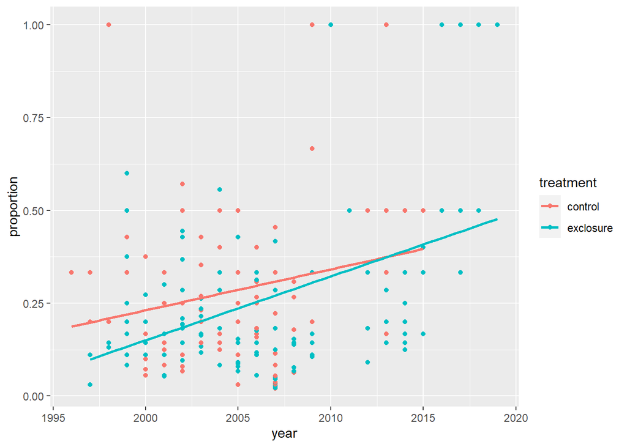

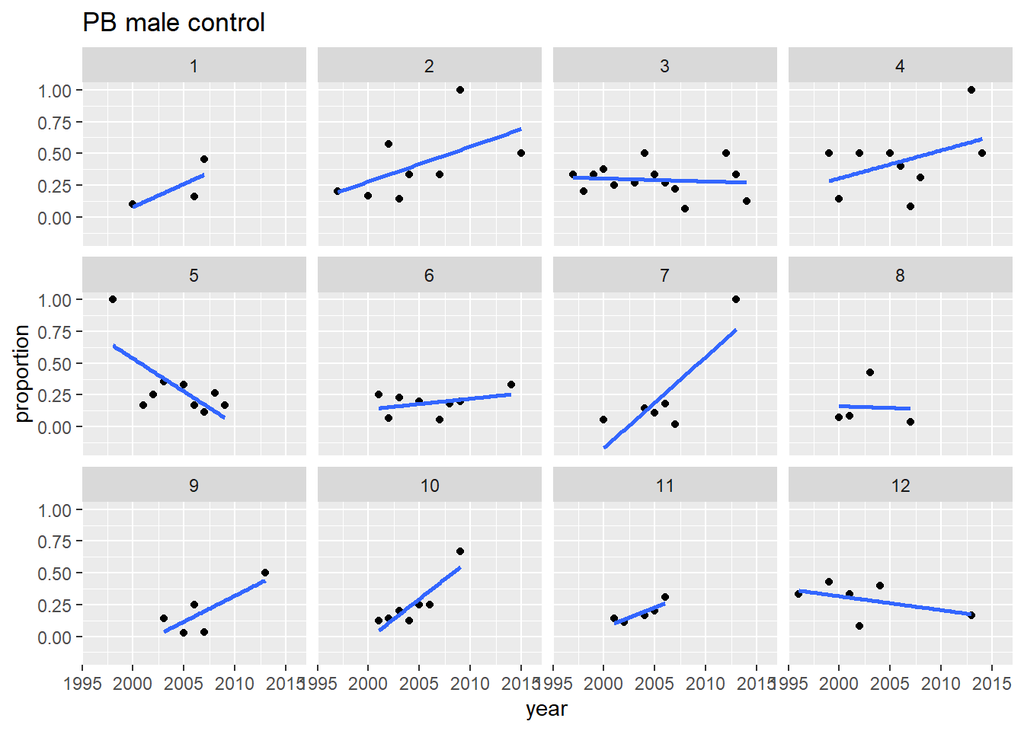

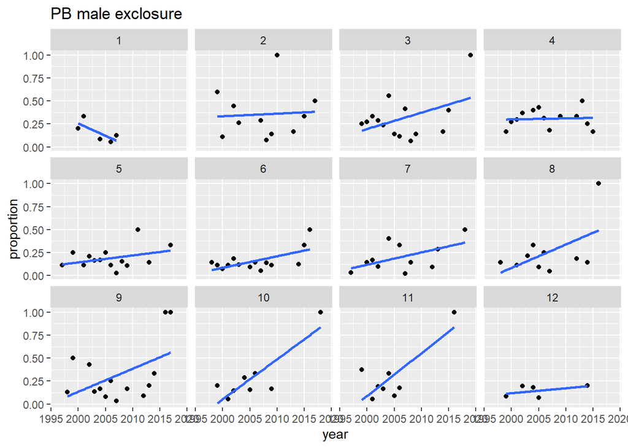

*Temporal Autocorrelation check*

```r
library(lmtest)

y=PB_dat_M$proportion
mod_lm=lm(proportion~year, data=PB_dat_M)
yrep=mod_lm$residuals
require(lmtest)
dwtest(yrep~PB_dat_M$year) #autocorrelation exists (DW=0.06, p < 0.05)
```

```
##
##  Durbin-Watson test
##
## data:  yrep ~ PB_dat_M$year
## DW = 0.064346, p-value < 2.2e-16
## alternative hypothesis: true autocorrelation is greater than 0
```

*Hierarchical BB with sine-cosine terms*

```r
#mod_cosin=stan(model_code="
#   data{
#  int<lower=0> N; // no.of obs
#  int <lower=0> y[N];       // reproductive indivs
#  int <lower=0>  n[N];       // total males
#  vector [N] year;// year
#  vector [N]mon_cos;//cosine month
#  vector [N]mon_sin;//sine of month
#  vector[N] treatment;// treatment
# }

# parameters {
#  real alpha;// intercept
#  real year_eff; //slope year
#  real trt_eff; //slope treatment effect
#  real monc_eff;
#  real mons_eff;
#  real <lower=0> phi;
#  real <lower=0, upper=1> pred_repro[N] ;//proportion of reproductive indivs
#              }

#  transformed parameters{
#  vector <lower=0, upper=1> [N] repro_mu; //so we can add statement describing proportion (not able to do in parameters block)
#  vector <lower=0> [N] A;
#  vector <lower=0> [N] B;

#  for (i in 1:N){

#  repro_mu[i]= inv_logit(alpha+ year_eff*year[i]+trt_eff*treatment[i]+monc_eff*mon_cos[i]+mons_eff*mon_sin[i]);
#  }

#  A = repro_mu * phi;
#  B = (1 - repro_mu)* phi;

#  }

# model {
#  //priors
#  alpha~normal(0,1);
#  year_eff~ normal (0,1);
#  trt_eff~ normal (0,1);
#  monc_eff~normal(0,1);
#  mons_eff~normal(0,1);
#  phi ~normal(0,1);

#  //model likelihood:

#  pred_repro ~ beta(A, B); //
#  y~binomial(n, pred_repro); //no.of reproductive males drawn from binomial dist; based on sample size and proportion

# }

#  generated quantities {

#  real pred_y [N];//predictions on proportions
#  real log_lik [N];// for looic calculations

#    pred_y = beta_rng(A, B);

#    for (x in 1:N){
#    log_lik[x]= beta_lpdf(pred_repro[x]| A[x], B[x]);}

# }    ", data=dat_list, chains=4, iter=3000)
PB_intyrtrtmon=readRDS("./model_output/PB_intyrtrtmon.RDS")

#model evaluation using LOOIC:
m3_loo=extract(PB_intyrtrtmon)$log_lik
loo(m3_loo) #-593.7+/- 27.7
```

```
##
## Computed from 6000 by 413 log-likelihood matrix
##
##          Estimate   SE
## elpd_loo    296.8 13.9
## p_loo       498.2 33.5
## looic      -593.7 27.7
## ------
## Monte Carlo SE of elpd_loo is NA.
##
## Pareto k diagnostic values:
##                          Count Pct.    Min. n_eff
## (-Inf, 0.5]   (good)     261   63.2%   730
##  (0.5, 0.7]   (ok)       116   28.1%   186
##    (0.7, 1]   (bad)       36    8.7%   62
##    (1, Inf)   (very bad)   0    0.0%   <NA>
## See help('pareto-k-diagnostic') for details.
```

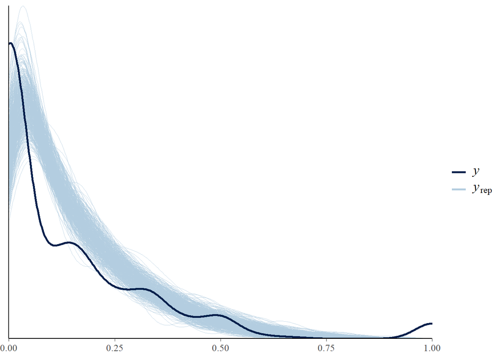

```r
#model evaluation using PPD(posterior predictive checks):
y=PB_dat_M$proportion
yrep=rstan::extract(PB_intyrtrtmon)$pred_y
yrep=as.matrix(yrep)
bayesplot::ppc_dens_overlay(y, yrep[1:500,])
```

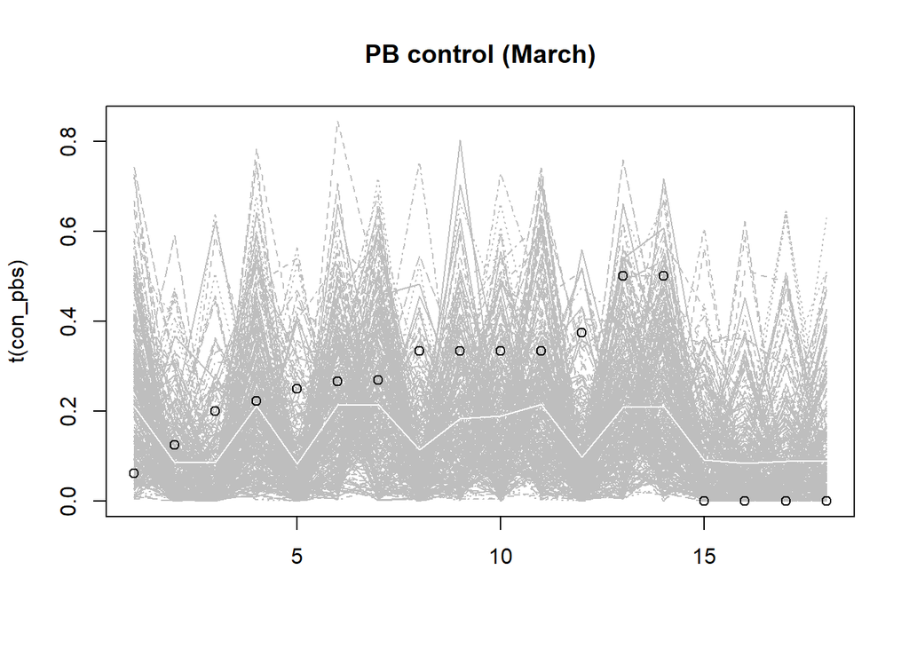

```r
con_pb=yrep[,which(PB_dat_M$treatment=="control"& PB_dat_M$month==3)]
con_pbmat=as.matrix(con_pb)
con_pbs=con_pbmat[1:300,]
matplot(t(con_pbs), type="l", col="grey", main="PB control (March)")
mean_con_pb=apply(con_pb, 2, mean)
con_pb_obs=PB_dat_M%>%filter(treatment=="control"& month==3)
lines(mean_con_pb~c(1:length(mean_con_pb)), col="white")
points(con_pb_obs$proportion, col="black", cex=1 )
```

```r
print(PB_intyrtrtmon, pars=c("alpha", "phi", "year_eff", "trt_eff", "monc_eff", "mons_eff"))
```

```
## Inference for Stan model: 72834439f61e2dde3c338a67f12691bb.
## 4 chains, each with iter=3000; warmup=1500; thin=1;
## post-warmup draws per chain=1500, total post-warmup draws=6000.
##
##           mean se_mean   sd  2.5%   25%   50%   75% 97.5% n_eff Rhat
## alpha    -1.83    0.00 0.12 -2.06 -1.91 -1.83 -1.75 -1.60  1587    1
## phi       5.78    0.02 0.57  4.73  5.37  5.76  6.17  6.93  1296    1
## year_eff  0.00    0.00 0.17 -0.33 -0.12  0.00  0.11  0.32  1351    1
## trt_eff   0.04    0.00 0.14 -0.23 -0.05  0.04  0.14  0.32  1932    1
## monc_eff -0.23    0.00 0.10 -0.43 -0.30 -0.23 -0.16 -0.03  1886    1
## mons_eff  0.51    0.00 0.10  0.31  0.44  0.51  0.58  0.71  1951    1
##
## Samples were drawn using NUTS(diag_e) at Tue Feb 09 16:01:29 2021.
## For each parameter, n_eff is a crude measure of effective sample size,
## and Rhat is the potential scale reduction factor on split chains (at
## convergence, Rhat=1).
```

*hierarchical BB model with AR1 term (more like intercept only actually)*

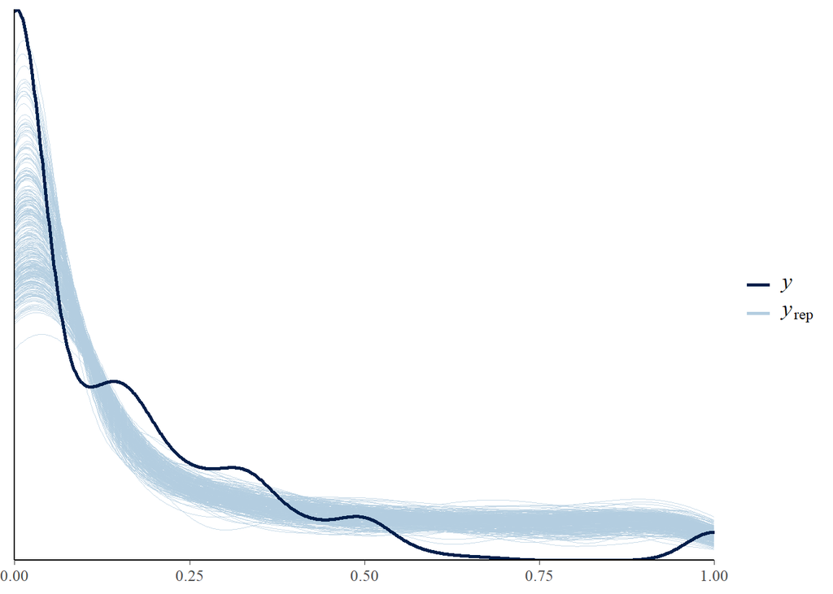

```r
# pbyr_autocor=stan(model_code=
# "functions { // adopt this function to add AR1 structure in Stan models: https://www.flutterbys.com.au/stats/tut/tut8.3b.html
#  matrix cov_matrix_ar1(real ar, real sigma, int nrows) {
#    matrix[nrows, nrows] mat;
#    vector[nrows - 1] gamma;
#    mat = diag_matrix(rep_vector(1, nrows));
#    for (i in 2:nrows) {
#      gamma[i - 1] = pow(ar, i - 1);
#      for (j in 1:(i - 1)) {
#        mat[i, j] = gamma[i - j];
#        mat[j, i] = gamma[i - j];
#      }     }
#    return sigma^2 / (1 - ar^2) * mat;
#  }}

#data {
#  int<lower=1> N;  // total number of observations
#  int <lower=0> y[N];       // reproductive indivs
#  int <lower=0>  n[N];       // total males
#}

# transformed data {
#  vector[N] se2 = rep_vector(0, N);
#}

#parameters {
#  real alpha;

#  real<lower=0> sigma;  // residual SD
#  real <lower=-1,upper=1> phi;  // autoregressive effects
#  real <lower=0, upper=1> pred_repro[N] ;//proportion of reproductive indivs
#  real <lower=0>psi;//overdispersion param
#}

#transformed parameters{
#  vector [N] repro_mu; //so we can add statement describing proportion (not able to do in parameters block)
#  vector[N] A;
#  vector [N] B;

#//model:

#  for (i in 1:N){

#  repro_mu[i]= inv_logit(alpha);
#  }

#  A = repro_mu * psi;
#  B = (1 - repro_mu)* psi;
#}

# model {

#  matrix[N, N] res_cov_matrix;
#  matrix[N, N] Sigma;
#  res_cov_matrix = cov_matrix_ar1(phi, sigma, N);
#  Sigma = res_cov_matrix + diag_matrix(se2);
#  Sigma = cholesky_decompose(Sigma);

#//likelihood:

#  alpha~normal(0,1);

#  psi~normal(0,1);
#  sigma ~ cauchy(0,5);

#  pred_repro ~beta (A,B);
#  y~ binomial(n, pred_repro);
#}

#generated quantities {

#  real pred_y [N];//predictions on proportions
#  real log_lik [N];// for looic calculations

#  pred_y = beta_rng(A, B);

#  for (x in 1:N){
#    log_lik[x]= beta_lpdf(pred_repro[x]| A[x], B[x]);}

#}", data=dat_list, chains=2, iter=300)

pbyr_autocor1=readRDS("./model_output/pbyr_autocor1.RDS")
yrep2=rstan::extract(pbyr_autocor1)$pred_y
bayesplot::ppc_dens_overlay(y, yrep2)
```

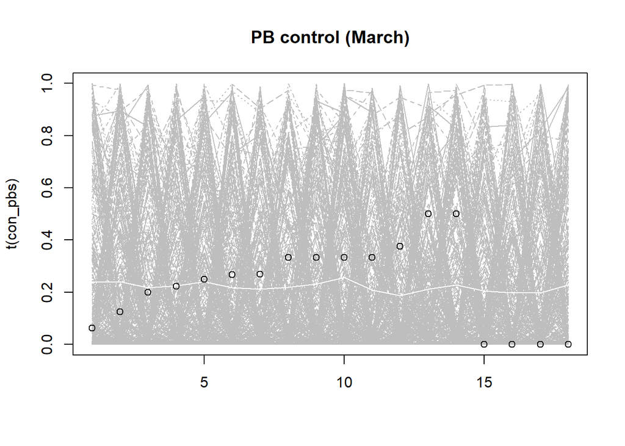

```r
con_pb=yrep2[,which(PB_dat_M$treatment=="control"& PB_dat_M$month==3)]
con_pbmat=as.matrix(con_pb)
con_pbs=con_pbmat[1:300,]
matplot(t(con_pbs), type="l", col="grey", main="PB control (March)")
mean_con_pb=apply(con_pb, 2, mean)
con_pb_obs=PB_dat_M%>%filter(treatment=="control"& month==3)
lines(mean_con_pb~c(1:length(mean_con_pb)), col="white")
points(con_pb_obs$proportion, col="black", cex=1 )
```

```r
print(pbyr_autocor1, pars=c("alpha"))
```

```
## Inference for Stan model: 3ef242c5b034b9d8c3f38b7d607cac10.
## 2 chains, each with iter=300; warmup=150; thin=1;
## post-warmup draws per chain=150, total post-warmup draws=300.
##
##        mean se_mean   sd  2.5%   25%   50%   75% 97.5% n_eff Rhat
## alpha -1.25    0.01 0.08 -1.42 -1.31 -1.25 -1.19 -1.09   132    1
##
## Samples were drawn using NUTS(diag_e) at Wed Feb 10 09:31:05 2021.
## For each parameter, n_eff is a crude measure of effective sample size,
## and Rhat is the potential scale reduction factor on split chains (at
## convergence, Rhat=1).
```

### **WOULD APPRECIATE YOUR THOUGHTS ON**

- How I’m interpreting what I’m doing right now is: I’m trying to describe what drives the proportion of reproductive individuals (breeding odds) but not really the “phenophases”/timing of reproduction (treating time as predictor and not really part of the response variable). Is this wrong? If yes, should I be creating metrics to describe when the 50% or 95% of the total reproductive individuals (or something) are counted? or for each year,determine the length of the “peak” season?
- how do you interpret the parameters for the sine-cosine terms?